## Code Challenges

#### 1. Simple decision tree

Example taken from Hazen (2014). Competing cancer and AIDS risks decision tree. Assume discrete time of single years. An individual starts in the `Well` state. They can transition into `Dead`, `Cancer & AIDS`, `Cancer`, `AIDS` or remain in the `Well` state.

Event probabilities are

- : Die from other causes

[figure not shown]

- : Die from recurent prostate cancer

[figure not shown]

- : Die from AIDS

[figure not shown]

- : Cancer recurs

[figure not shown]

- : Develop AIDS

#### 2. Markov-cycle tree

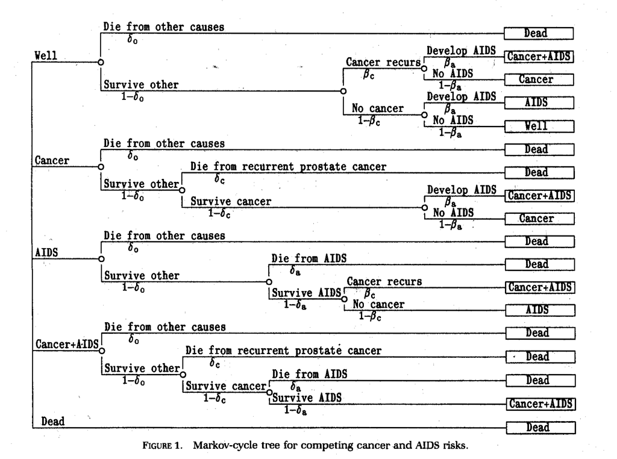

#### 3. Discrete-time Markov model

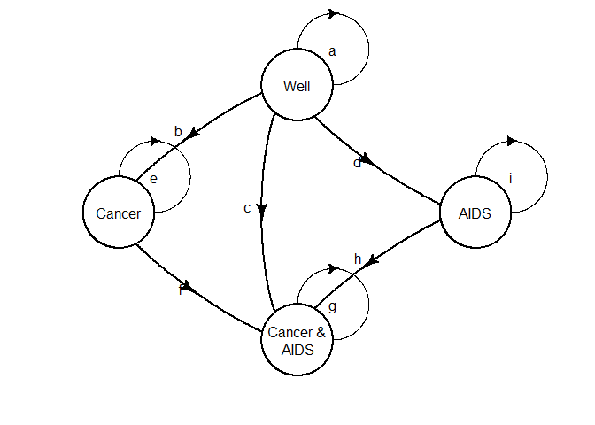

##### Calculate mean QALYs

Calculate cumulative proportion of patient cycles in each state and take product with health utilities for each respectively.

Define the state utilities :

- `Well`: 1.0
- `Cancer`: 0.60
- `AIDS`: 0.50
- `Cancer & AIDS`: 0.30
- `Dead`: 0

#### 4. One-cycle Markov-cycle tree

We can rearrange the Markov-cycle tree to closer resemble to Markov model by collapsing the branches into a single cycle and simply combining the probabilities.

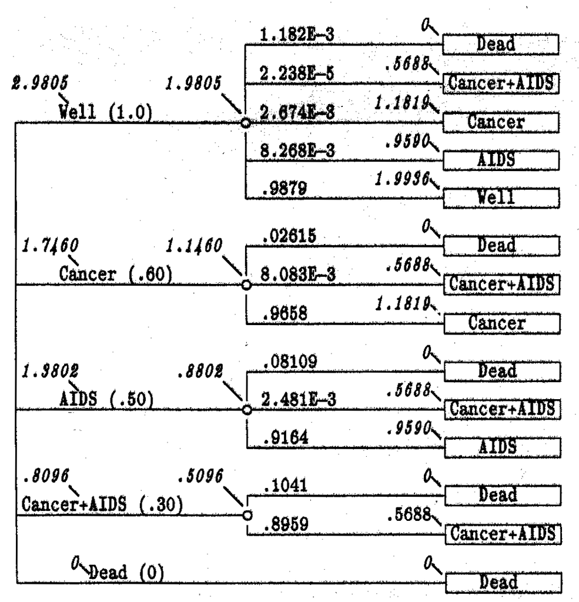

#### 6. Roll back Markov-cycle tree

We can calculate the mean QALYs using the markov-cycle tree representation without calculating the cumulative proportion of time of patient cycles in each health state. This is done by rolling back using the recursive equation ([value iteration](https://en.wikipedia.org/wiki/Markov_decision_process#Value_iteration)):

[figure not shown]

#### 5. Roll back stochastic tree

So far we have only considered discrete time. The Markov-cycle tree representation can be extended to continuous time as a *stochastic tree*. Probabilities are now replaced by rates. This change is represented by zigzag lines in the diagrams. This is clearly a more compact representation.

We can calculate mean QALY in an analogous way to the discrete-time case by rolling back using the recursive equation:

[figure not shown]

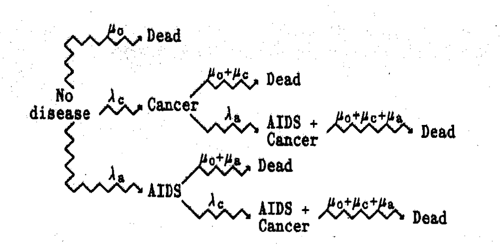

- `Cancer`:

[figure not shown]

  /year
- `AIDS`:

[figure not shown]

  /year
- `Dead from Cancer`:

[figure not shown]

  /year
- `Dead from AIDS`:

[figure not shown]

  /year
- `Dead other`:

[figure not shown]

  /year

### References

Hazen, Gordon B. 2014. “Stochastic Trees : A New Technique for Temporal Medical Decision Modeling,” no. August 1992. https://doi.org/10.1177/0272989X9201200302.